# New York City COVID-19 Detailed Situation Report

Author: Dhivya Ravindran

New York Cityhas become the epicenter of the COVID-19 Pandemic in the US. This report is dedicated to understanding how COVID-19 has spread through the different areas, boroughs and neighborhoods of New York City. This is a one time report, please read the data variability clause at the end of the report.

## Number of COVID-19 Confirmations by NYC Zipcode

This plot shows that COVID-19 has NOT attacked all neighbourhoods in the city equally. Lower Manhattan zip codes 10006, 10004, 10280, 10007 and 10005 had all less than 26 cases. In fact most of the COVID-19 cases were in the outer boroughs of the city, particularly Brooklyn, Bronx and Queens. Perhaps this could mean that COVID-19 cut across the socio economic divide, with high median income and white collar neighborhoods having less confirmations compared to low median income and blue collar neighborhoods.

The MTA ridership in those affected zip codes could be another reason for high COVID-19 incidence in the areas, with white collar workers being able to WFH while blue collar workers still had to use the MTA to get to their jobs. This has been studied [here](https://untappedcities.com/2020/03/18/mapping-the-nyc-subway-ridership-drop-from-coronavirus/), the ridership drop in MTA was more pronounced in affluent neighborhoods.

West Queens, Borough Park, Greenpoint, Bronx Park and Fordham were the hardest hit neighborhoods. Perhaps the correlation between median income and COVID-19 confirmations could be the subject of another detailed study.

COVID-19 Cases by ZipCode

[interactive chart not shown]

## Cases Per 100k Population for each of NYC’s Boroughs

COVID-19 Case Density by Boroughs

| Borough | CasesPer100kPopl | PoplEstimate2018 |
| --- | --- | --- |
| BRONX | 633.72 | 1432132 |
| BROOKLYN | 490.49 | 2582830 |
| MANHATTAN | 396.47 | 1628701 |
| QUEENS | 679.53 | 2278906 |
| STATEN ISLAND | 555.36 | 476179 |

## Bivariate Study for NYC w.r.t Age and Gender

Demographic study is the most interesting and insightful for the fact that it gives us an idea about what kind of patients are most vulnerable to COVID-19 related hospitalization and death. More patient data if made available can be used to build a risk model which predicts or rather quanitifies the risk for a person to be hospitalized/ dead due to COVID-19. The initial bi-variate study with respect to age and gender are shown below:

Men were more susceptible to hospitalization and death compared to women with hospitalization and death rates of 23.18% and 3.58% resp compared to 19.09% and 2.62% for women in NYC.

COVID-19 Hospitalization Rates and Death Rates with Gender

| Gender | CasesPer100kPopl | HospitalizedPer100kPopl | DeathsPer100kPopl | HospitalizationRate | FatalityRate |
| --- | --- | --- | --- | --- | --- |
| Female | 511.86 | 97.71 | 13.41 | 19.09 | 2.62 |
| Male | 677.86 | 157.14 | 24.24 | 23.18 | 3.58 |

Ages 75 and older were the most susceptiblefor COVID-19 with hospitalization rates of 50.36% and death rates of an astronomical 14.82%. 65-75 age range was also susceptible with hospitalization rates of 37.74% and death rates of 6.17%

COVID-19 Hospitalization Rates and Death Rates with Age

| AgeGroup | CasesPer100kPopl | HospitalizedPer100kPopl | DeathsPer100kPopl | HospitalizationRate | FatalityRate |
| --- | --- | --- | --- | --- | --- |
| 0-17 years | 51.02 | 5.10 | 0.06 | 10.00 | 0.12 |
| 18-44 years | 602.82 | 53.92 | 2.67 | 8.94 | 0.44 |
| 45-64 years | 851.00 | 192.70 | 18.58 | 22.64 | 2.18 |
| 65-75 years | 871.81 | 328.99 | 53.78 | 37.74 | 6.17 |
| 75 and older years | 879.56 | 442.98 | 130.35 | 50.36 | 14.82 |

## Time Series Curves for NYC (With New Delta)

Though the overall cumulative case counts are increasing, overall number of new tests conducted, confirmations, hospitalizations and deaths for 24 hrs window is showing a downward trend for the past few days for NYC.

COVID-19 Time Series Curves for NYC

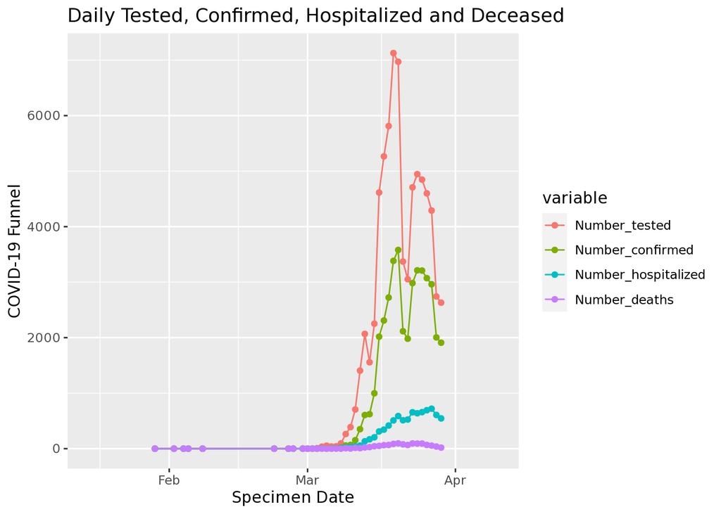

Data Sources: New York City Department of Health and The NY Times. Data Variability: Due to a static data set, data is variable and this report should only be used to study trends and not to track live numbers. Please refer to the daily situation report for that.